# R Notebook

Time Series Assignment

Q1 a. What’s the difference between time series modeling and regression analysis? Time series enable us to look at relationships over time to identify trends, but linear regression does not show the elapsed time factor. In linear regression, the data might not be necessarily independent and is not necessarily identically distributed. For time series, it’s a list of observations where the ordering will affect the result of the outcome. The ordering is very important as there is dependency and changing the order will change the correlation.

2. What’s the difference between decompose and stl?

STL is a more advanced technique to extract seasonality, in the sense that is allows seasonality to vary, which is not the case in decompose. The stl command does an additive decomposition in which a Lowess smoother is used to estimate the trend and the seasonal effects. The decompose command only does the seasonal effects but not the trend effects. The decompose command assumes seasonal component repeats from year to year, but stl command can capture the varying effect in the seasonality.

3. How do we find the seasonality of a time series?

We will use the method of Seasonal Decomposition to find out the seasonal patterns. If data shows some seasonality (e.g. daily, weekly, quarterly, yearly) it may be useful to decompose the original time series into the sum of three components, including the seasonal component S(t), the trend-cycle component T(t), and the remainder component R(t). The classical decomposition estimates trend T(t) through a rolling mean and computes S(t) as the average detrended series to get the seasonality factor.

4. What are the benefits of TBATS over ARIMA?

The TBATS forecasting model based on exponential smoothing. The main feature of TBATS model is its capability to deal with multiple seasonalities by modelling each seasonality with a trigonometric representation based on Fourier series. The ARIMA model assume only one seasonality factor and cannot identity multiple seasonalities. The TBATS has advantages in providing more accurate results in forecasting data with multiple seasonlities that have different patterns.

5. Describe 2 time series models

Exponential Smoothing is used for smoothing time series data using the exponential windon function. The forecast gives a weighted average of the past observations and exponential functions are used to assign exponentially decreasing weights over time.

Vector autoregression (VAR) is a used to capture the relationship between multiple quantities as they change over time. The Var model generalizes the univariate autoregressive model by allowing for multivariate time series.

Q2 a) From the graph, we can tell that consumption is a non-stationarity graph with an upward trend. It increases over the time when the time passes and could possibly have a seasonal oscillation characteristics (Increasing in a few years and then follows by a decrease)

As a result I will recommend to take seasonal non-stationarity differences so diff(consumption, 4) is taken into considerations.

As consumption data is a curved upward trend accompanied by increasing variance, I will also recommend to transform the series with logarithm. As a result, a log transformation is needed.

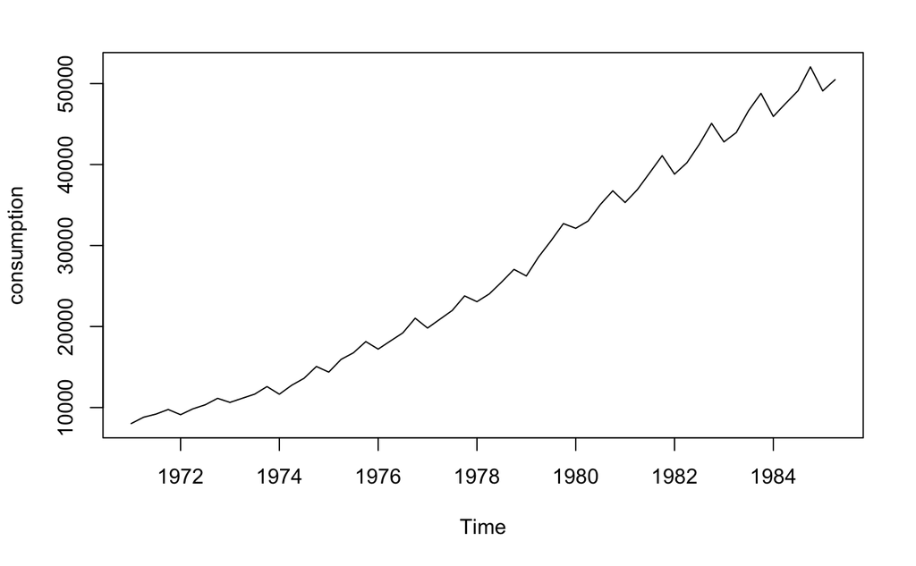

```r
library("Ecdat")
data(IncomeUK)
consumption = IncomeUK[,2]
y = log(consumption)
plot(consumption)

par(mfrow=c(4,1))
```

```r
plot(y, main = "Plotting the Original Graph")
plot(diff(y), main = "Differencing out Non-Seasonal Non-Stationarity")
```

```r
plot(diff(y,4), main = "Differencing out Seasonal Non-Stationarity")
plot(diff(diff(y),4), main = "Differencing out Seasonal+Non-Seasonal Non-Stationarity")
```

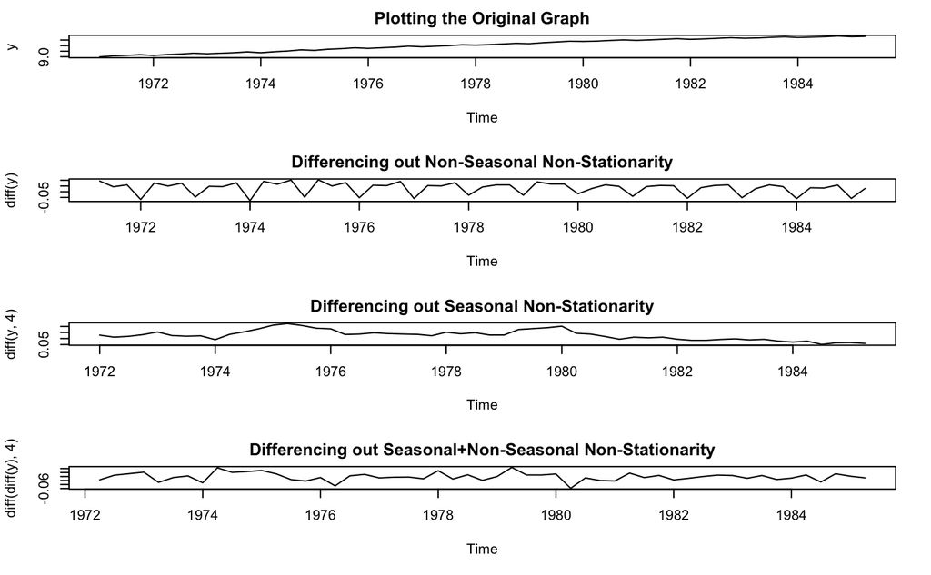

```r
par(mfrow=c(1,1))
```

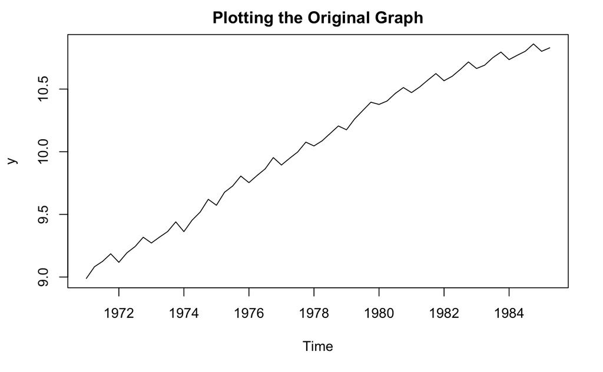

```r
plot(y, main = "Plotting the Original Graph")
```

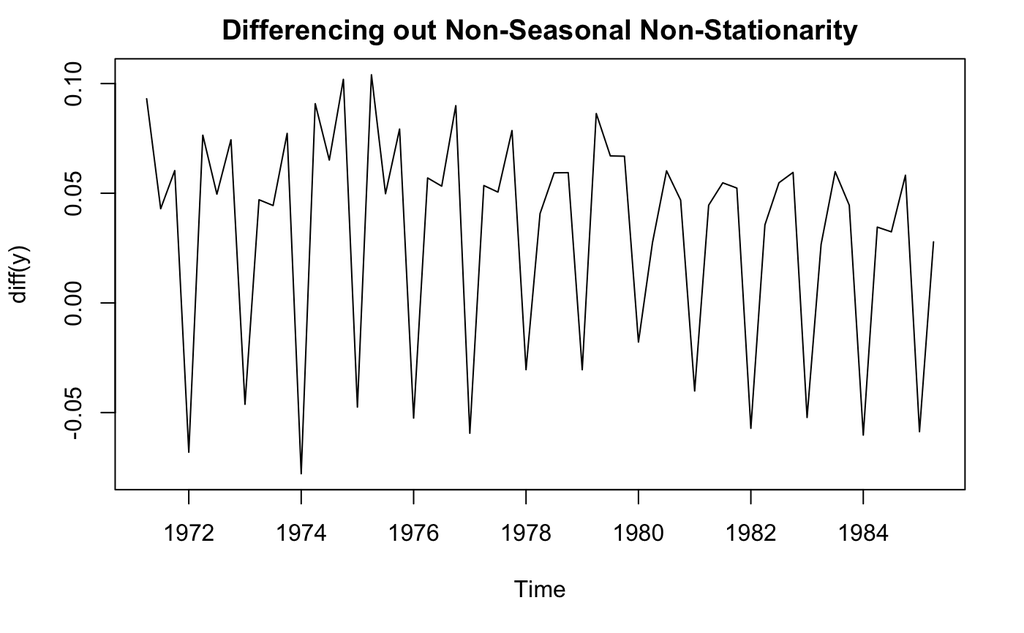

```r
plot(diff(y), main = "Differencing out Non-Seasonal Non-Stationarity")
```

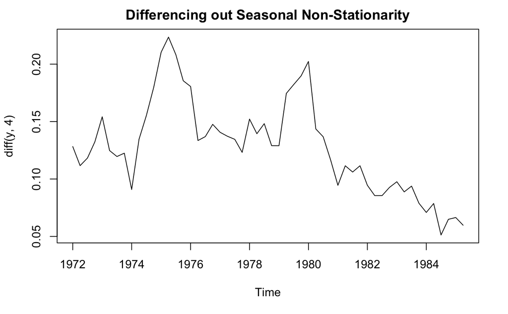

```r
plot(diff(y,4), main = "Differencing out Seasonal Non-Stationarity")
```

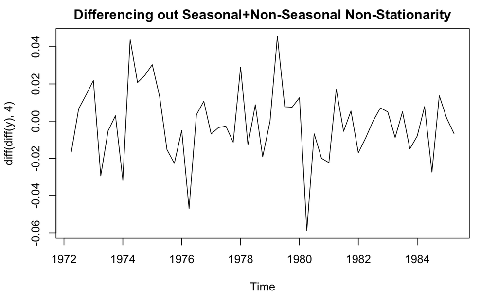

```r
plot(diff(diff(y),4), main = "Differencing out Seasonal+Non-Seasonal Non-Stationarity")
```

```r
par(mfrow=c(4,1))
acf(y, main = "Plotting the Original Graph")
acf(diff(y), main = "Differencing out Non-Seasonal Non-Stationarity")
```

```r
acf(diff(y,4), main = "Differencing out Seasonal Non-Stationarity")
acf(diff(diff(y),4), main = "Differencing out Seasonal+Non-Seasonal Non-Stationarity")
```

[figure not shown]

```r
par(mfrow=c(1,1))
```

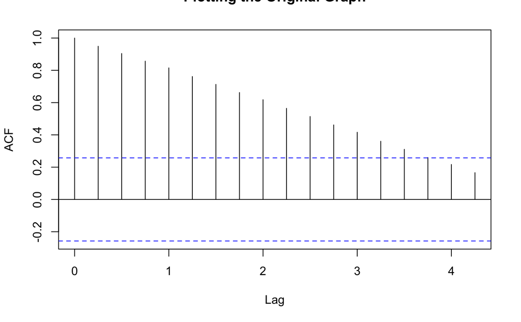

```r
acf(y, main = "Plotting the Original Graph")
```

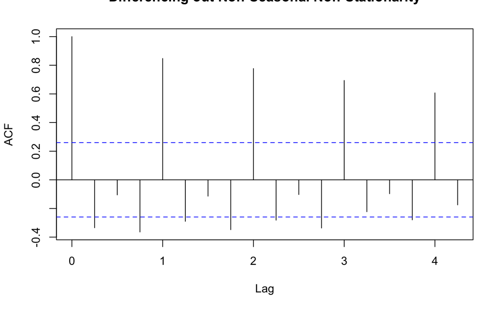

```r
acf(diff(y), main = "Differencing out Non-Seasonal Non-Stationarity")
```

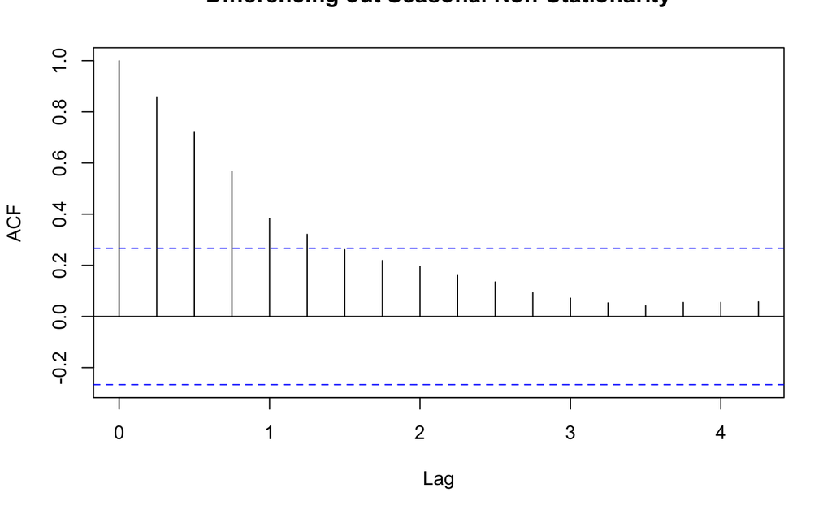

```r
acf(diff(y,4), main = "Differencing out Seasonal Non-Stationarity")
```

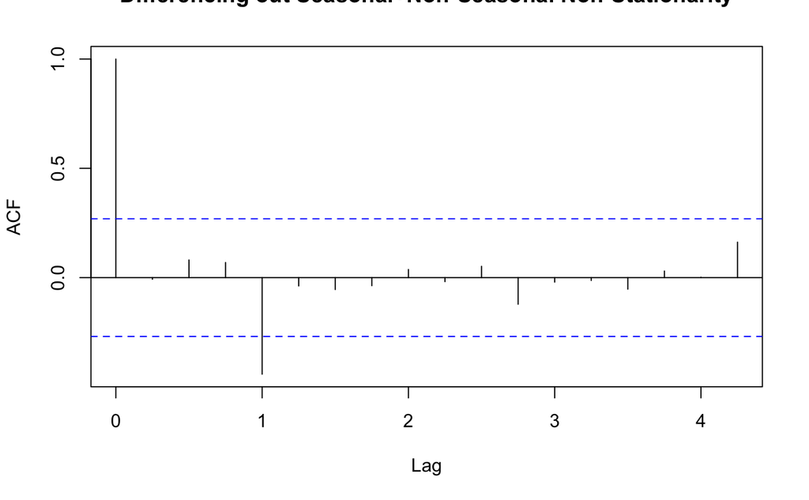

```r
acf(diff(diff(y),4), main = "Differencing out Seasonal+Non-Seasonal Non-Stationarity")
```

Given the the previous acf graphs, we will use ARIMA(0,1,1)(0,1,1)[4] model with non-seasonal order c(0,1,1) and seasonal components c(0,1,1).

```r
fit1 = arima(y, c(0,1,1),seasonal = list(order =c(0,1,1), period = 4))
fit1
```

```
Call:
arima(x = y, order = c(0, 1, 1), seasonal = list(order = c(0, 1, 1), period = 4))

Coefficients:
         ma1     sma1
      0.0031  -0.5347
s.e.  0.1157   0.1164

sigma^2 estimated as 0.0002923:  log likelihood = 139.77,  aic = -273.55
```

3. When we conduct the the residual check, we find out the acf graph shows no autocorrelations after the first period. When we conduct the Ljung-Box Test, it shows a p-value of 0.659556.

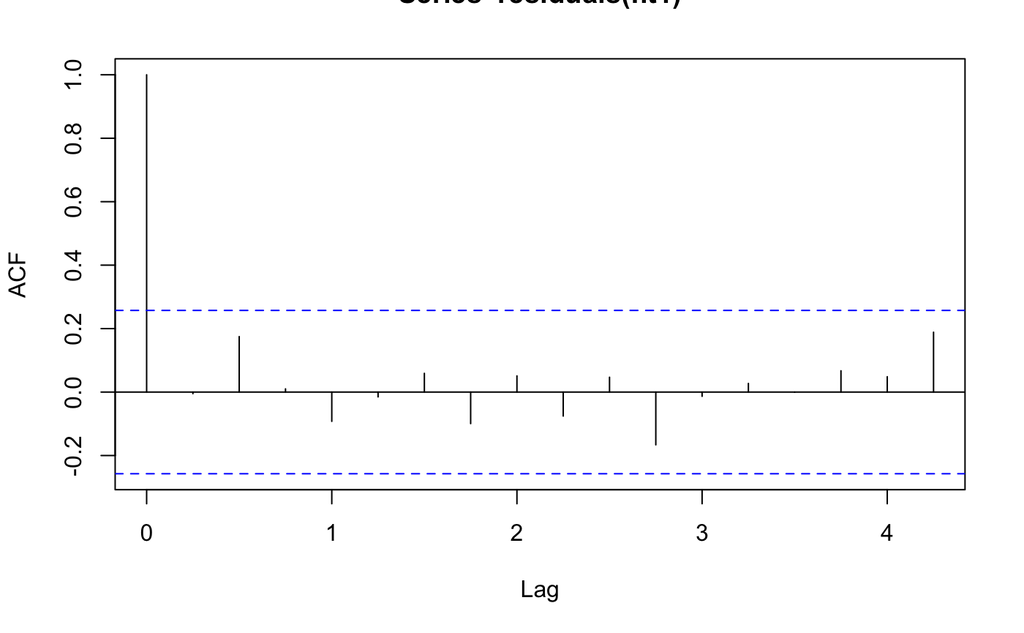

```r
acf(residuals(fit1))
```

```r
Box.test(residuals(fit1), type="Ljung-Box", lag = 10, fitdf=4)
```

```
    Box-Ljung test

data:  residuals(fit1)
X-squared = 4.1265, df = 6, p-value = 0.6596
```

4. The model selected is ARIMA(0,1,0)(0,1,1)[4] using BIC.

```r
library(forecast)
autofit = auto.arima(y,ic = 'bic')
autofit
```

```
Series: y
ARIMA(0,1,0)(0,1,1)[4]

Coefficients:
         sma1
      -0.5348
s.e.   0.1164

sigma^2 estimated as 0.0003056:  log likelihood=139.77
AIC=-275.55   AICc=-275.31   BIC=-271.61
```

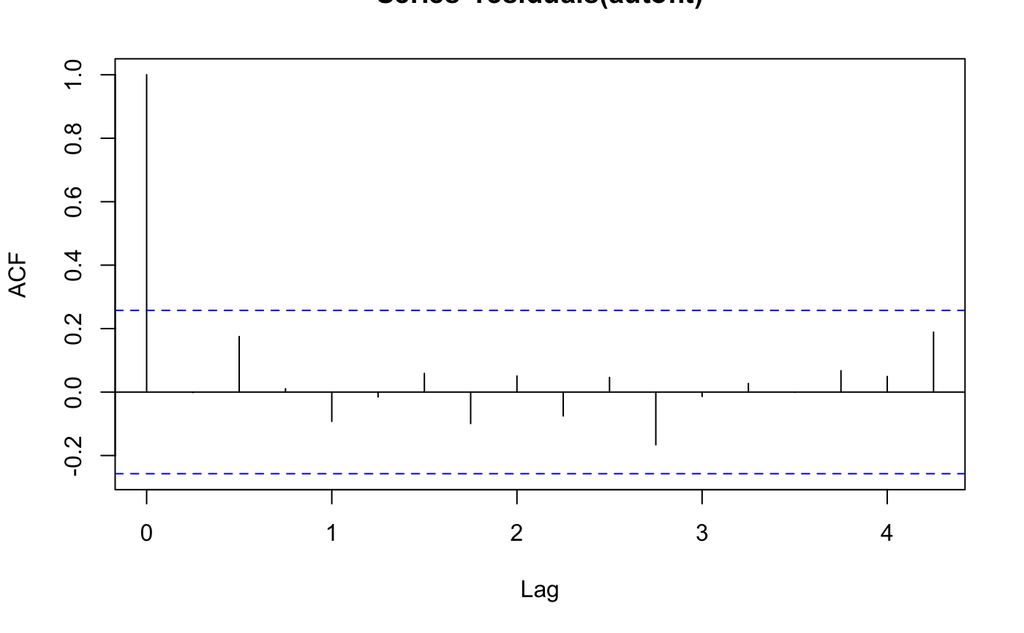

```r
acf(residuals(autofit))
```

```r
Box.test(residuals(autofit), lag = 10, fitdf =2)
```

```
    Box-Pierce test

data:  residuals(autofit)
X-squared = 3.6642, df = 8, p-value = 0.8861
```

```r
fitAutoArima = auto.arima(log(consumption),ic="bic")
foreAutoArima = forecast(fitAutoArima,h=8)


fit <- arima(log(consumption), order = c(0,1,1),seasonal = list(order = c(0,1,1)))
fit = predict(fit, n.ahead = 8)

par(mfrow=c(2,1))
plot(foreAutoArima,xlim=c(1985.5,1987.5),ylim=c(10.86,11))
plot(fit$pred,xlim=c(1985.5,1987.5),ylim=c(10.86,11), main = "Forecast from Question b ARIMA(0,1,1)(0,1,1)[4]")
```

[output not shown]

Q3 a) Since the data is a upward trend so a logrithm transformation is required.

```r
# Monthly one-month T-bill rates
library(Ecdat)
data(Mishkin)
tb1 = log(Mishkin[,3])
plot(tb1)

acf(tb1)

plot(diff(tb1))

acf(diff(tb1))
```

[output not shown]

```r
arima(tb1,order = c(1,0,0))
arima(tb1,order = c(3,0,0))
arima(diff(tb1),order = c(1,0,0))
```

[output not shown]

```r
fitaic = auto.arima(tb1, max.P = 0,max.Q=0, ic = "aic")
fitaic
fitbic = auto.arima(tb1, max.P = 0,max.Q=0, ic = "bic")
fitbic
acf(residuals(fitaic), main="Using aic")
acf(residuals(fitbic),main="Using bic")
```

[output not shown]

```r
fitaic = auto.arima(tb1, max.P = 0,max.Q=0, ic = "aic")
fitaic
acf(residuals(fitaic))
Box.test(residuals(fitaic), lag = 10, fitdf =5)
```

[output not shown]

```r
tb1aic = auto.arima(tb1, ic = "aic")
tb1aic
tb1bic = auto.arima(tb1, ic = "bic")
tb1bic
```

[output not shown]

```r
acf(residuals(tb1aic))
acf(residuals(tb1bic))
Box.test(residuals(tb1aic), lag = 12, fitdf =2)
Box.test(residuals(tb1bic), lag = 12, fitdf =2)
```

[output not shown]

4 a) Using Garch Model AR(1)/GARCH(1,1) to look at the changes on the interest rate, which allows the white noise to have a non-Gaussian distribution.

```r
library(fGarch)
library(Ecdat)
data(Irates)
r = as.numeric(log(Irates[,2]))
n = length(r)
lagr = r[1:(n-1)]
diffr = r[2:n] - lagr
```

2. the parameters are as follows:

```r
irates.garch.std = garchFit(~arma(1,0)+garch(1,1),data=diffr, cond.dist = "std")
```

[output not shown]

[output not shown]

[output not shown]

[output cut: 8 more lines]

[output not shown]

```r
irates.garch.std
```

```
Title:
 GARCH Modelling

Call:
 garchFit(formula = ~arma(1, 0) + garch(1, 1), data = diffr, cond.dist = "std")

Mean and Variance Equation:
 data ~ arma(1, 0) + garch(1, 1)
<environment: 0x7fda98df2c78>
 [data = diffr]

Conditional Distribution:
 std

Coefficient(s):
        mu         ar1       omega      alpha1       beta1       shape
0.00910873  0.09508060  0.00054864  0.32444019  0.74026870  2.83060758

Std. Errors:
 based on Hessian

Error Analysis:
        Estimate  Std. Error  t value Pr(>|t|)
mu     0.0091087   0.0023895    3.812 0.000138 ***
ar1    0.0950806   0.0432758    2.197 0.028014 *
omega  0.0005486   0.0002968    1.848 0.064564 .
alpha1 0.3244402   0.1368876    2.370 0.017782 *
beta1  0.7402687   0.0656629   11.274  < 2e-16 ***
shape  2.8306076   0.4243716    6.670 2.56e-11 ***
---
Signif. codes:  0 ‘***’ 0.001 ‘**’ 0.01 ‘*’ 0.05 ‘.’ 0.1 ‘ ’ 1

Log Likelihood:
 630.9167    normalized:  1.190409

Description:
 Tue Aug 10 11:53:26 2021 by user:
```

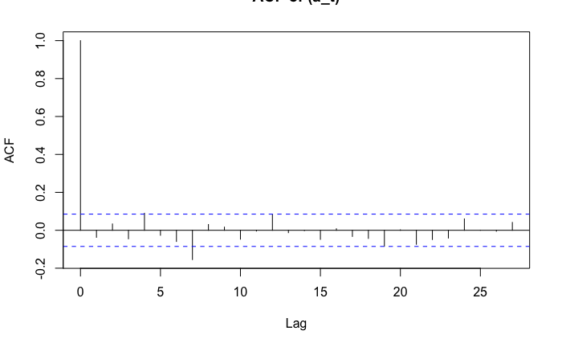

```r
acf(residuals(irates.garch.std), main="ACF of (a_t)")
```

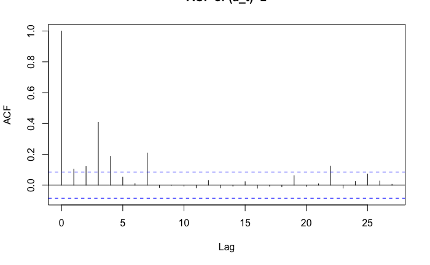

```r
acf(residuals(irates.garch.std)^2, main="ACF of (a_t)^2")
```

For getting the graphs

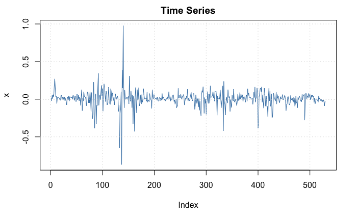

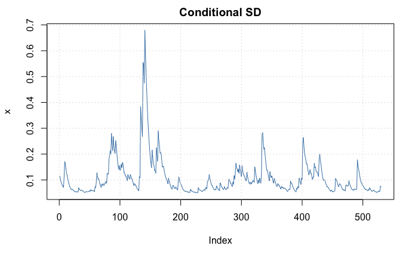

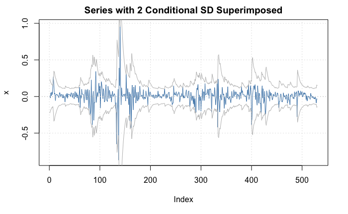

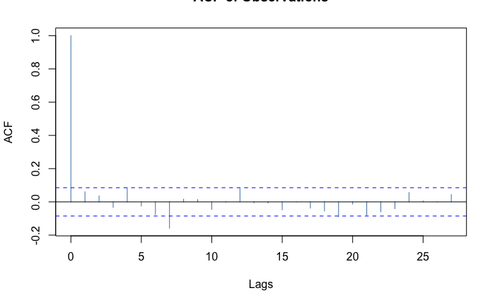

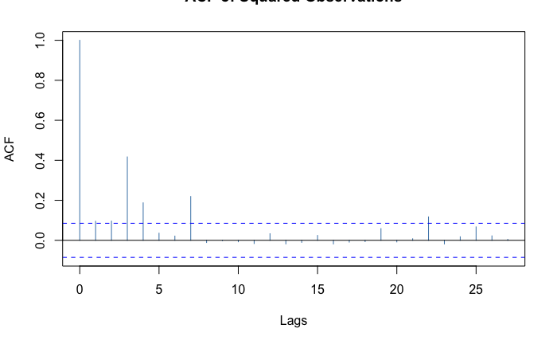

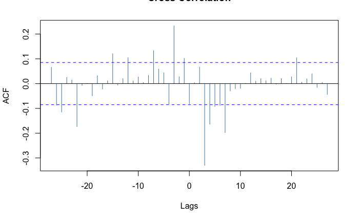

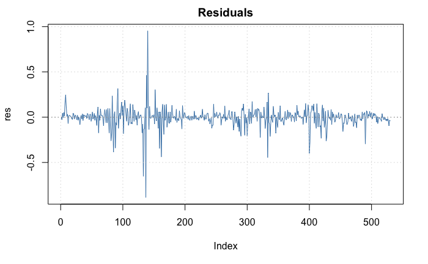

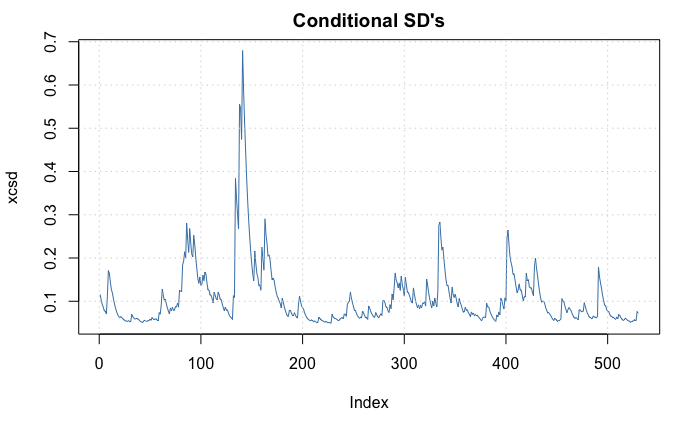

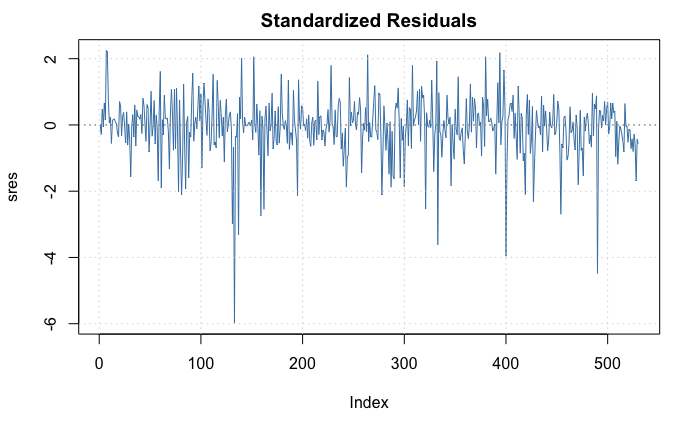

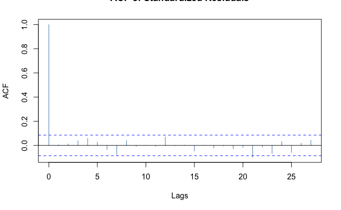

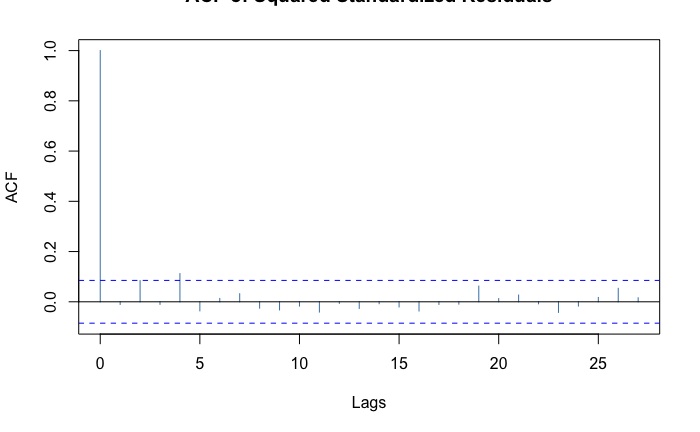

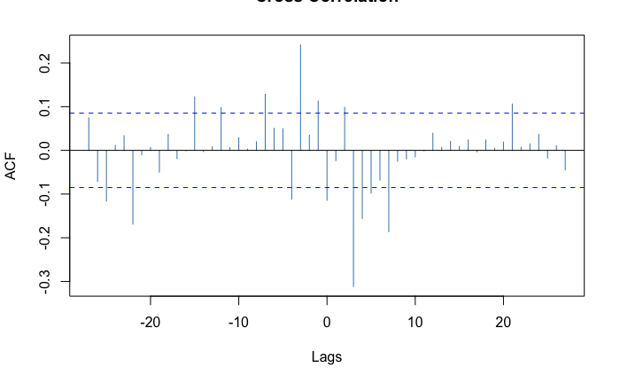

```r
library(xts)
plot(irates.garch.std, which="all")
```

[figure not shown]

```r
par(mfrow = c(3,2))
```

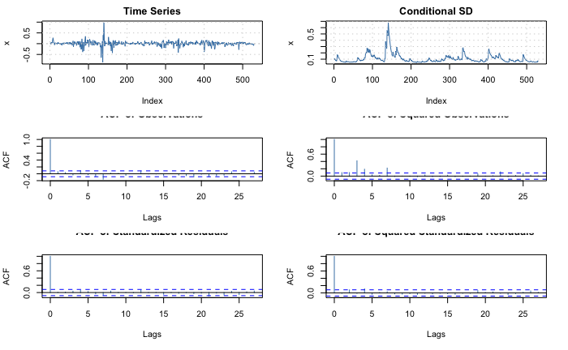

```r
for(i in c(1,2,4,5,10,11))
  plot(irates.garch.std,
which=i)
```

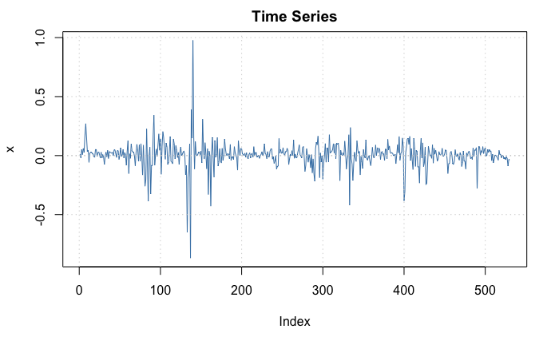

```r
par(mfrow = c(1,1))
for(i in c(1))
  plot(irates.garch.std,
which=i)
```

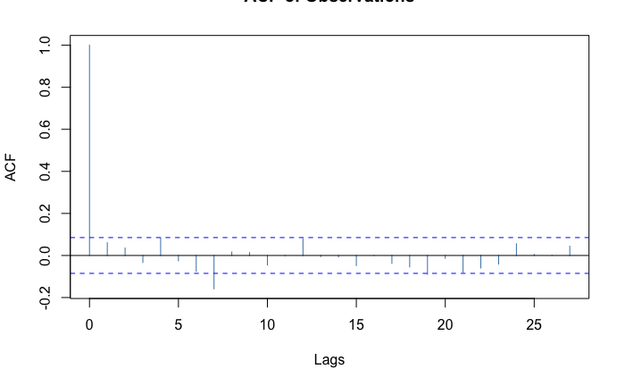

```r
par(mfrow = c(1,1))
for(i in c(4))
  plot(irates.garch.std,
which=i)
```

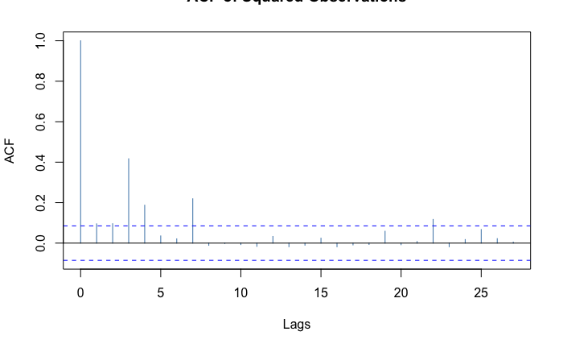

```r
par(mfrow = c(1,1))
for(i in c(5))
  plot(irates.garch.std,
which=i)
```

Q5.

Getting the stock data HSBC 0005.HK from 2011-01-01 to 2021-07-30 and taking adjusted close price daily.

```r
require(quantmod)
Sys.setenv(TZ = "UTC")

start_date <- "2011-01-01"
end_date <- "2021-07-30"

symbols <- c("0005.HK")
#download the prices
getSymbols(Symbols=symbols, src = "yahoo", index.class = "POSIXct",
           from = start_date,
           to = end_date)
stock<-get(symbols[1])[,6]

plot(stock)
priceTimeSeries =  stock$'0005.HK.Adjusted'
priceTimeSeries = priceTimeSeries[complete.cases(priceTimeSeries),]
stock = priceTimeSeries
```

[output not shown]

taking log transformation and look at the acf graph for original and log transform data

```r
logstock = log(stock) #take log of the data

acf(logstock)
pacf(logstock)
acf(diff(logstock)[-1,])
pacf(diff(logstock)[-1,])
```

[output not shown]

```r
model1 <- auto.arima(stock)
model1

forecast_model = forecast(model1, h=200)
forecast_model
plot(forecast_model, ylim=c(0,80))

acf(residuals(model1))


Box.test(residuals(model1), lag = 5, type = "Ljung", fitdf = 3)
```

[output not shown]

Using garch model to fit for the parameter

```r
library(fGarch)
logstock = diff(log(stock))
logstock =logstock[-1,]
model1 <- garchFit(formula = ~arma(0, 1) + garch(1, 1), data = logstock)
model1@fit$ics[1] # AIC
model1@fit$ics[2] # BIC
```

[output not shown]

```r
resultsdiff <- matrix(0, nrow=20, ncol=4)
table_index <- 1
for (i in 1:4){
  for (j in 1:5){
    model1 <- garchFit(substitute(~arma(p, 1) + garch(q, 1), list(p=i, q=j)), data = logstock)
    resultsdiff[table_index,1] = i
    resultsdiff[table_index,2] = j
    resultsdiff[table_index,3] = model1@fit$ics[1] # This is AIC
    resultsdiff[table_index,4] = model1@fit$ics[2] # This is BIC
    table_index <- table_index + 1
  }
}

resultsdiff <- as.data.frame(resultsdiff)
colnames(resultsdiff) <- c('P', 'Q', 'AIC', 'BIC')

resultsdiff[which.min(resultsdiff$AIC),]
```

[output not shown]

using naive & snaive model to get the stock forestcast

```r
library(fpp2)
library(forecast)
plot(stock)
stockvec =as.vector(stock)
par(mfrow=c(2,1))
model = naive(stockvec)
plot(predict(model, n.ahead=24), xlim=c(2580,2630))
model = snaive(stockvec)
plot(predict(model, n.ahead=24), xlim=c(2580,2630))
```

[output not shown]